# **Water Quality Prediction Analysis**

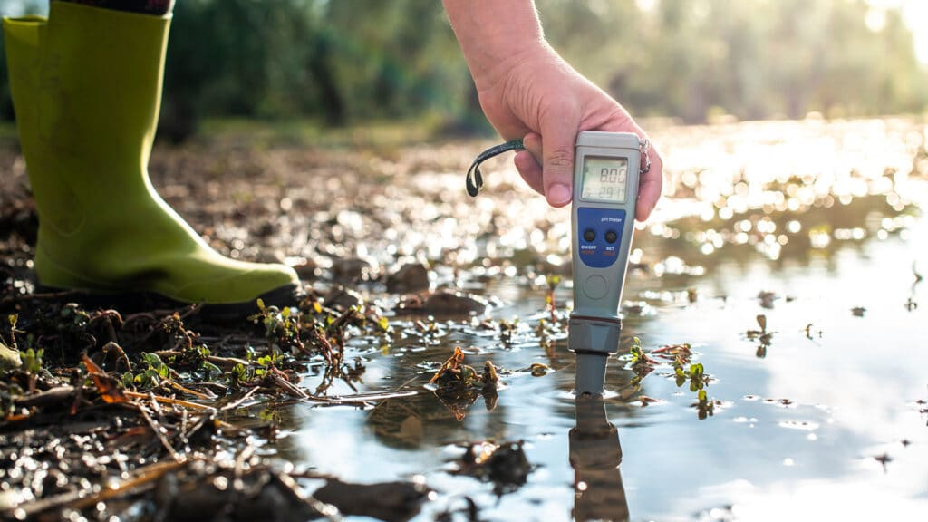

**What is water quality?**

Water quality refers to the chemical, physical, and biological characteristics of water based on the standards of its usage.

**Management of water quality is a real-world issue !!**

Over time, there has been increasing recognition of the importance of drinking water quality and its impact on public health. This has led to increasing protection and management of water quality.

**What is potability?**

Potable water, or water suitable for human consumption, is water that can be used for drinking, cooking, hygiene, and other household chores.

# **Aim of Project**

This project aims to find the best-fit model to predict the water potability based on a dataset which contains water quality metrics for 3276 different water bodies.

The goal is to correctly classify water samples as potable (1) or not potable (0).

# Reading the data

```python
# importing necessary libraries
import numpy as np
import pandas as pd
import matplotlib.pyplot as plt
import seaborn as sns
from sklearn.preprocessing import StandardScaler
from sklearn.model_selection import train_test_split, GridSearchCV
from sklearn.metrics import accuracy_score
```

```python
# handling warnings
import warnings
warnings.filterwarnings('ignore')
```

```python
# reading the csv file and storing it in a variable
df=pd.read_csv('/content/water_potability.csv')
```

```python
# printing the first 5 rows of the dataset
df.head()
```

|  | ph | Hardness | Solids | Chloramines | Sulfate | Conductivity | Organic_carbon | Trihalomethanes | Turbidity | Potability |
| --- | --- | --- | --- | --- | --- | --- | --- | --- | --- | --- |
| 0 | NaN | 204.890455 | 20791.318981 | 7.300212 | 368.516441 | 564.308654 | 10.379783 | 86.990970 | 2.963135 | 0 |
| 1 | 3.716080 | 129.422921 | 18630.057858 | 6.635246 | NaN | 592.885359 | 15.180013 | 56.329076 | 4.500656 | 0 |
| 2 | 8.099124 | 224.236259 | 19909.541732 | 9.275884 | NaN | 418.606213 | 16.868637 | 66.420093 | 3.055934 | 0 |
| 3 | 8.316766 | 214.373394 | 22018.417441 | 8.059332 | 356.886136 | 363.266516 | 18.436524 | 100.341674 | 4.628771 | 0 |
| 4 | 9.092223 | 181.101509 | 17978.986339 | 6.546600 | 310.135738 | 398.410813 | 11.558279 | 31.997993 | 4.075075 | 0 |

```python
# checking the number of rows & columns in the dataset
df.shape
```

```
(3276, 10)
```

```python
# applying info() on dataset
df.info()
```

```
<class 'pandas.core.frame.DataFrame'>
RangeIndex: 3276 entries, 0 to 3275
Data columns (total 10 columns):
 #   Column           Non-Null Count  Dtype
---  ------           --------------  -----
 0   ph               2785 non-null   float64
 1   Hardness         3276 non-null   float64
 2   Solids           3276 non-null   float64
 3   Chloramines      3276 non-null   float64
 4   Sulfate          2495 non-null   float64
 5   Conductivity     3276 non-null   float64
 6   Organic_carbon   3276 non-null   float64
 7   Trihalomethanes  3114 non-null   float64
 8   Turbidity        3276 non-null   float64
 9   Potability       3276 non-null   int64
dtypes: float64(9), int64(1)
memory usage: 256.1 KB
```

- We can observe that there are no columns with categorical data.
- Hence, we only need to apply preprocessing for numerical data.

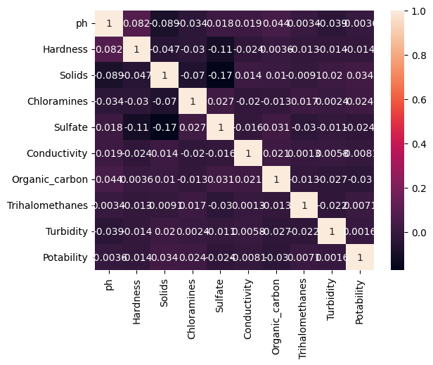

```python
# plotting a correlation heatmap to represent the correlation between multiple variables
sns.heatmap(df.corr(),annot=True)
```

# Preprocessing of data

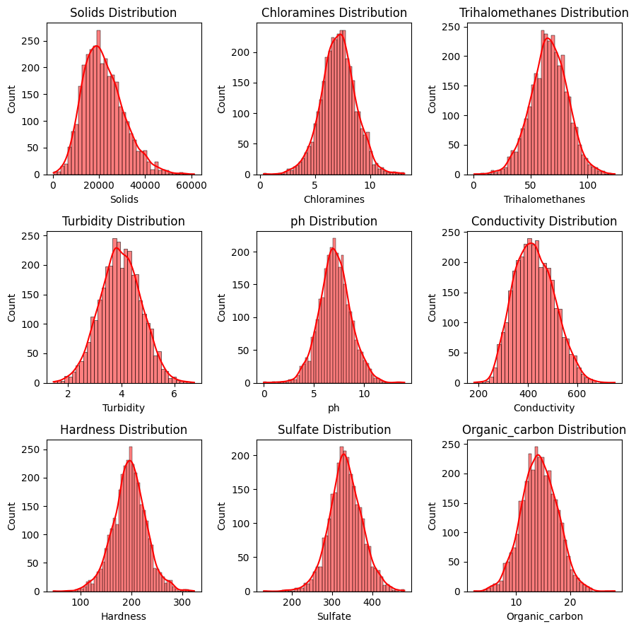

```python
# visualizing parameter correlation with potability
dist = df.corr()['Potability'].sort_values(ascending=False)
plt.figure(figsize = (9, 9))

for i, col in enumerate(dist.index[1:], 1):
    plt.subplot(3, 3, i)
    sns.histplot(df[col], kde = True, color='Red')
    plt.title(col+" Distribution")
    plt.tight_layout()
    plt.plot()
```

```python
# checking if there are any missing values
df.isnull().sum()
```

```
ph                 491
Hardness             0
Solids               0
Chloramines          0
Sulfate            781
Conductivity         0
Organic_carbon       0
Trihalomethanes    162
Turbidity            0
Potability           0
dtype: int64
```

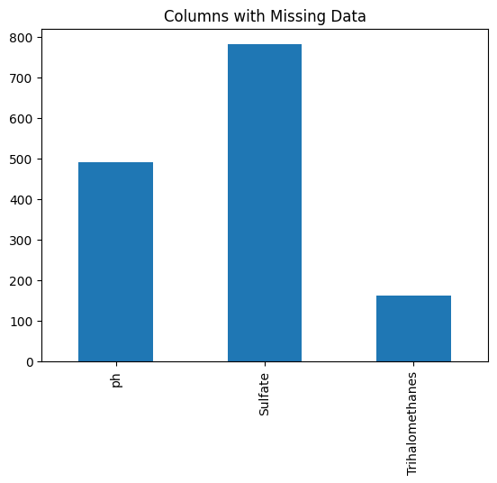

```python
# visualizing the columns which have missing values
plt.title('Columns with Missing Data')
df.isna().sum()[df.isna().sum()>0].plot(kind='bar')
```

```python
# handling missing data
# replacing the missing values with the mean values of each column
df[['ph','Sulfate','Trihalomethanes']] = df[['ph','Sulfate','Trihalomethanes']].fillna(df[['ph','Sulfate','Trihalomethanes']].mean())
df.head()
```

|  | ph | Hardness | Solids | Chloramines | Sulfate | Conductivity | Organic_carbon | Trihalomethanes | Turbidity | Potability |
| --- | --- | --- | --- | --- | --- | --- | --- | --- | --- | --- |
| 0 | 7.080795 | 204.890455 | 20791.318981 | 7.300212 | 368.516441 | 564.308654 | 10.379783 | 86.990970 | 2.963135 | 0 |
| 1 | 3.716080 | 129.422921 | 18630.057858 | 6.635246 | 333.775777 | 592.885359 | 15.180013 | 56.329076 | 4.500656 | 0 |
| 2 | 8.099124 | 224.236259 | 19909.541732 | 9.275884 | 333.775777 | 418.606213 | 16.868637 | 66.420093 | 3.055934 | 0 |
| 3 | 8.316766 | 214.373394 | 22018.417441 | 8.059332 | 356.886136 | 363.266516 | 18.436524 | 100.341674 | 4.628771 | 0 |
| 4 | 9.092223 | 181.101509 | 17978.986339 | 6.546600 | 310.135738 | 398.410813 | 11.558279 | 31.997993 | 4.075075 | 0 |

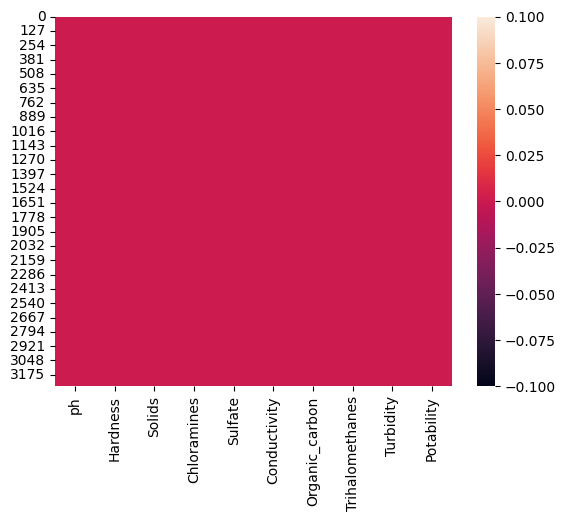

```python
# plotting a heatmap to visualize that we have got rid of all missing data
sns.heatmap(df.isnull())
```

```python
# separating into input data X and target variable y
X = df.drop('Potability', axis=1)
y = df['Potability']
```

- Since most of the parameters have normal distribution, we can apply StandardScaler for feature scaling.

```python
# scaling the numerical data using StandardScaler()
StandardScaler().fit_transform(X)
```

```
array([[-6.04313345e-16,  2.59194711e-01, -1.39470871e-01, ...,
        -1.18065057e+00,  1.30614943e+00, -1.28629758e+00],
       [-2.28933938e+00, -2.03641367e+00, -3.85986650e-01, ...,
         2.70597240e-01, -6.38479983e-01,  6.84217891e-01],
       [ 6.92867789e-01,  8.47664833e-01, -2.40047337e-01, ...,
         7.81116857e-01,  1.50940884e-03, -1.16736546e+00],
       ...,
       [ 1.59125368e+00, -6.26829230e-01,  1.27080989e+00, ...,
        -9.81329234e-01,  2.18748247e-01, -8.56006782e-01],
       [-1.32951593e+00,  1.04135450e+00, -1.14405809e+00, ...,
        -9.42063817e-01,  7.03468419e-01,  9.50797383e-01],
       [ 5.40150905e-01, -3.85462310e-02, -5.25811937e-01, ...,
         5.60940070e-01,  7.80223466e-01, -2.12445866e+00]])
```

# Applying GridSearchCV on 6 algorithms to find the best model

Algorithms used are as follow:

- Logistic Regression
- Decision Tree Classifier
- Random Forest Classifier
- K-Nearest Neighbours
- SVM
- XGBoost

For each algorithm we will train the model on training data and test its accuracy of prediction when tested on testing data.

Finally, we will compare the accuracy of various models used.

```python
# splitting into training & testing data
X_train, X_test, y_train, y_test = train_test_split(X, y, test_size=0.25, random_state=0)
```

```python
# importing necessary libraries
from sklearn.linear_model import LogisticRegression
from sklearn.tree import DecisionTreeClassifier
from sklearn.ensemble import RandomForestClassifier
from sklearn.neighbors import KNeighborsClassifier
from sklearn.svm import SVC
from xgboost import XGBClassifier
```

**Logistic Regression**

```python
clf = GridSearchCV(LogisticRegression(multi_class='multinomial', max_iter=500), {'C':[1,5,10,15]}, cv=5)
clf.fit(X_train,y_train)
clf.best_score_
```

```
0.6096865530773434
```

```python
clf.best_params_
```

```
{'C': 15}
```

```python
lg = accuracy_score(y_test, clf.predict(X_test))
print(lg)
```

```
0.6117216117216118
```

**Decision Tree Classifier**

```python
clf = GridSearchCV(DecisionTreeClassifier(), { 'criterion': ['gini','log loss', 'entropy'], 'max_depth': [2, 4, 6, 8],'min_samples_split': [2, 5, 10],  'min_samples_leaf': [1, 2, 4]} , cv=5)
clf.fit(X_train,y_train)
clf.best_score_
```

```
0.6454953388637754
```

```python
clf.best_params_
```

```
{'criterion': 'gini',
 'max_depth': 8,
 'min_samples_leaf': 4,
 'min_samples_split': 10}
```

```python
dt = accuracy_score(y_test, clf.predict(X_test))
print(dt)
```

```
0.6227106227106227
```

**Random Forest Classifier**

```python
clf = GridSearchCV(RandomForestClassifier(), { 'criterion': ['gini', 'entropy'], 'max_depth': [2, 4, 6, 8],'min_samples_split': [2, 5, 10],  'min_samples_leaf': [1, 2, 4]} , cv=5)
clf.fit(X_train,y_train)
clf.best_score_
```

```
0.6581168347325022
```

```python
clf.best_params_
```

```
{'criterion': 'gini',
 'max_depth': 8,
 'min_samples_leaf': 2,
 'min_samples_split': 2}
```

```python
rf = accuracy_score(y_test, clf.predict(X_test))
print(rf)
```

```
0.6617826617826618
```

**K-Nearest Neighbours**

```python
clf = GridSearchCV(KNeighborsClassifier(), { 'n_neighbors': [3, 5, 7, 9],'weights': ['uniform', 'distance'],'algorithm': ['auto', 'ball_tree', 'kd_tree', 'brute']}, cv=5, scoring='accuracy')
clf.fit(X_train,y_train)
clf.best_score_
```

```
0.5714321196165119
```

```python
clf.best_params_
```

```
{'algorithm': 'auto', 'n_neighbors': 9, 'weights': 'uniform'}
```

```python
knn = accuracy_score(y_test, clf.predict(X_test))
print(knn)
```

```
0.5592185592185592
```

**Support Vector Machine (SVM)**

```python
clf = GridSearchCV(SVC(), {'C': [0.1, 1, 10, 100], 'gamma': [1, 0.1, 0.01, 0.001], 'kernel': ['rbf']}, cv=5)
clf.fit(X_train,y_train)
clf.best_score_
```

```
0.6088727170367426
```

```python
clf.best_params_
```

```
{'C': 0.1, 'gamma': 1, 'kernel': 'rbf'}
```

```python
svc = accuracy_score(y_test, clf.predict(X_test))
print(svc)
```

```
0.612942612942613
```

**XGBoost**

```python
clf = GridSearchCV(XGBClassifier(), {'max_depth': [2, 4, 6, 8], 'n_estimators': [50, 100, 125, 150], 'learning_rate': [0.01, 0.03, 0.05]}, cv=5)
clf.fit(X_train,y_train)
clf.best_score_
```

```
0.66136472770023
```

```python
clf.best_params_
```

```
{'learning_rate': 0.03, 'max_depth': 6, 'n_estimators': 150}
```

```python
xg = accuracy_score(y_test, clf.predict(X_test))
print(xg)
```

```
0.6715506715506715
```

# Comparing Accuracy

```python
# creating a new dataset with 2 columns : Model names & Accuracy scores
models = pd.DataFrame({
    'Model':['Logistic Regression', 'Decision Tree', 'Random Forest', 'KNeighbours', 'SVM', 'XGBoost'],
    'Accuracy' :[lg, dt, rf, knn, svc, xg]
     })

# sorting the data in increasing order of accuracy score
models.sort_values(by='Accuracy')
```

|  | Model | Accuracy |
| --- | --- | --- |
| 3 | KNeighbours | 0.559219 |
| 0 | Logistic Regression | 0.611722 |
| 4 | SVM | 0.612943 |
| 1 | Decision Tree | 0.622711 |
| 2 | Random Forest | 0.661783 |
| 5 | XGBoost | 0.671551 |

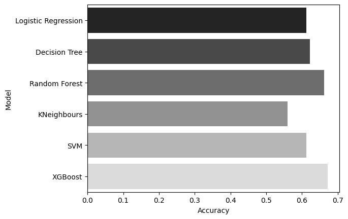

```python
# visualizing the comparison
sns.barplot(x='Accuracy', y='Model', palette='gray', data=models)
```

[output not shown]

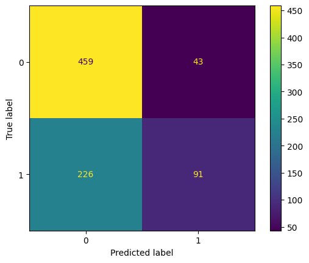

```python
# plotting confusion matrix for XGBoost
from sklearn.metrics import confusion_matrix, ConfusionMatrixDisplay
ConfusionMatrixDisplay(confusion_matrix(y_test, clf.predict(X_test))).plot()
```

# **Conclusion**

XGBoost has highest accuracy among the 6 algorithms. Hence, XGBoost is best model for water quality prediction for this dataset.